# HW6-Fall2022

```r
# Set up the default parameters
# 1. The code block will be shown in the document
# 2. set up figure display size
# 3. turn off all the warnings and messages

knitr::opts_chunk$set(echo = TRUE)
knitr::opts_chunk$set(fig.width = 8, fig.height = 4)
knitr::opts_chunk$set(warning = FALSE, message = FALSE)
```

## Background

Individuals stock prices tend to exhibit high amounts of non-constant variance, and thus ARIMA models build upon that data would likely exhibit non-constant variance in residuals. In this problem we are going to analyze the Intel stock price data from 2012 through end of 2021. We will use the ARIMA-GARCH to model daily and weekly stock price (adjusted close price at the end of a day for daily data or at the end of the week for weekly data), with a focus on the behavior of its volatility as well as forecasting both the price and the volatility.

## Data import and cleaning

```r
## Libraries used within this homework are uploaded here
library(zoo,warn.conflicts=FALSE)
library(lubridate,warn.conflicts=FALSE)
library(mgcv,warn.conflicts=FALSE)
library(rugarch,warn.conflicts=FALSE)
library(ggplot2)
```

```r
#importing the data
dailydata <- read.csv("INTCDaily.csv", head = TRUE)
weeklydata <- read.csv("INTCWeekly.csv", head = TRUE)
#cleaning the data
#dates to date format
weeklydata$Date<-as.Date(weeklydata$Date,format='%m/%d/%y')
dailydata$Date<-as.Date(dailydata$Date,format='%m/%d/%y')

#prices to timeseries format
INTWeekly <- ts(weeklydata$Adj.Close,start=c(2012,1,1),freq=52)
INTDaily <- ts(dailydata$Adj.Close,start=c(2012,1,1),freq=252)
```

# Question 1: Exploratory Data Analysis (20 points)

**1a.** Based on your intuition, when would you use daily vs weekly stock price data?

*Response: Question 1a*

Daily stock price data is expected to experience more changes and be more chaotic than the weekly data. I would use the daily data if the goal was to predict future trends on a daily basis. Likewise, I would use weekly data if the expectations were for predictions to be at the weekly granularity.

**1b.** Plot the time series plots comparing daily vs weekly data. How do the daily vs weekly time series data compare?

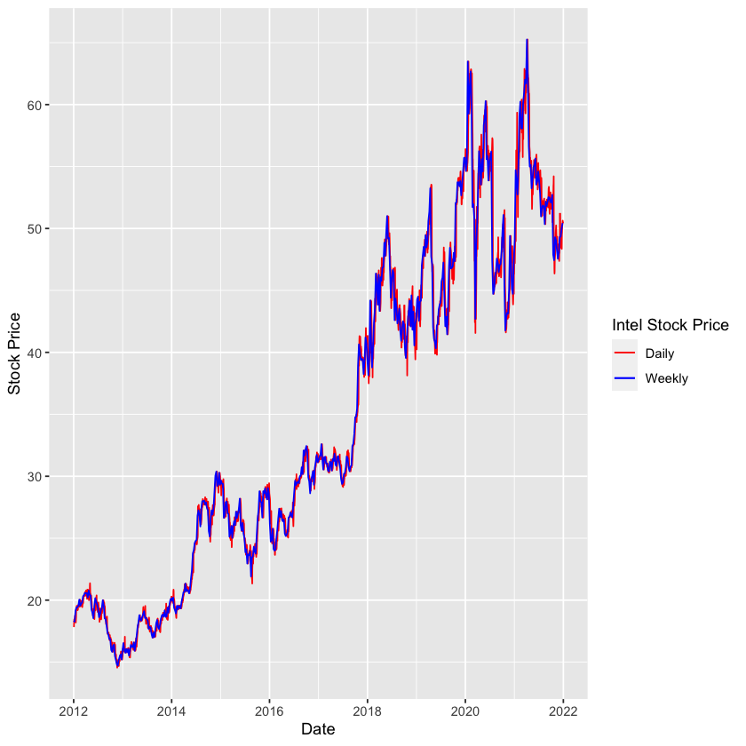

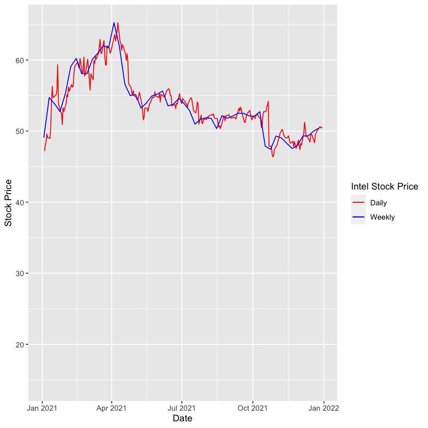

```r
ggplot() +
  geom_line(data = dailydata, aes(x = Date, y = Adj.Close, color="Daily")) +
  geom_line(data = weeklydata, aes(x = Date, y = Adj.Close, color = "Weekly")) +
  xlab('Date') +
  ylab('Stock Price') + scale_color_manual(name='Intel Stock Price',
                     breaks=c('Daily', 'Weekly'),
                     values=c('Daily'='red', 'Weekly'='blue'))

ggplot() +
  geom_line(data = dailydata, aes(x = Date, y = Adj.Close, color="Daily")) +
  geom_line(data = weeklydata, aes(x = Date, y = Adj.Close, color = "Weekly")) +
  xlab('Date') + xlim(as.Date(c('2021-01-01','2021-12-31'))) +
  ylab('Stock Price') + scale_color_manual(name='Intel Stock Price',
                     breaks=c('Daily', 'Weekly'),
                     values=c('Daily'='red', 'Weekly'='blue'))
```

*Response: Question 1b*

As expected the weekly data is a smoothed version of the daily data. The weekly data doesn't expereience the peaks and valleys experienced by the daily data but does follow the same trend. To show this phenomena clearly I plotted the data just for calendar year 2021.

**1c.** Fit a non-parametric trend using splines regression to both the daily and weekly time-series data. Overlay the fitted trends. How do the trends compare?

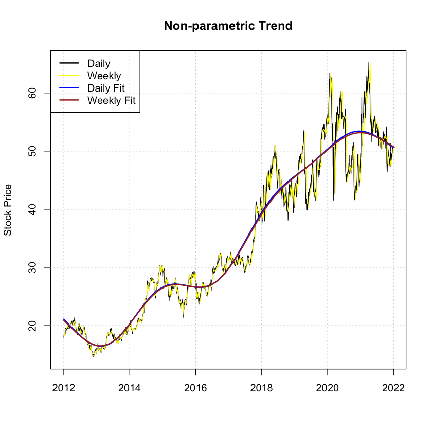

```r
# Daily Data

points_daily <- 1:nrow(dailydata)
points_daily <- (points_daily - min(points_daily)) / max(points_daily)

gam.w.daily <- gam(INTDaily ~ s(points_daily))
gam.w.daily.fit <- ts(fitted(gam.w.daily), start=c(2012,1,1),freq=252)

# Weekly Data

points_weekly <- 1:nrow(weeklydata)
points_weekly <- (points_weekly - min(points_weekly)) / max(points_weekly)

gam.w.weekly <- gam(INTWeekly ~ s(points_weekly))
gam.w.weekly.fit <- ts(fitted(gam.w.weekly), start=c(2012,1,1),freq=52)

# Plot
ts.plot(INTDaily, xlab = "", ylab = "Stock Price",
        main = "Non-parametric Trend")
grid()
lines(INTWeekly, col="yellow")
lines(gam.w.daily.fit, lwd=2, col="blue")
lines(gam.w.weekly.fit, lwd=2, col="brown")
legend("topleft", legend = c("Daily", "Weekly", "Daily Fit", "Weekly Fit"),
col = c("black", "yellow", "blue", "brown"), lwd = 2)
```

*Response: Question 1c*

The trends of the weekly and daily data follow very closely together. They do deviate slightly from 2018 to 2022 in times of high volitility.

**1d.** Consider the return stock price computed as provided in the canvas homework assignment. Apply this formula to compute the return price based on the daily and weekly time series data. Plot the return time series and their corresponding ACF plots. How do the return time series compare in terms of stationarity and serial dependence?

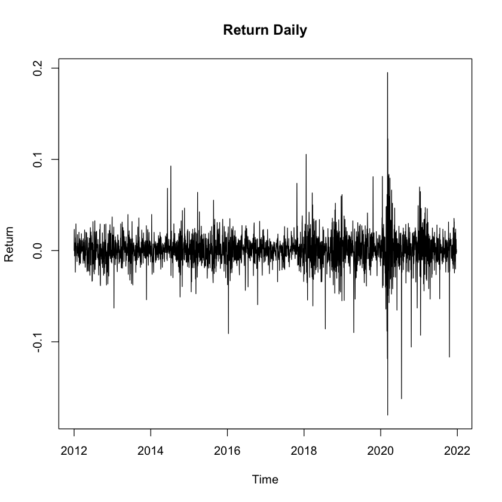

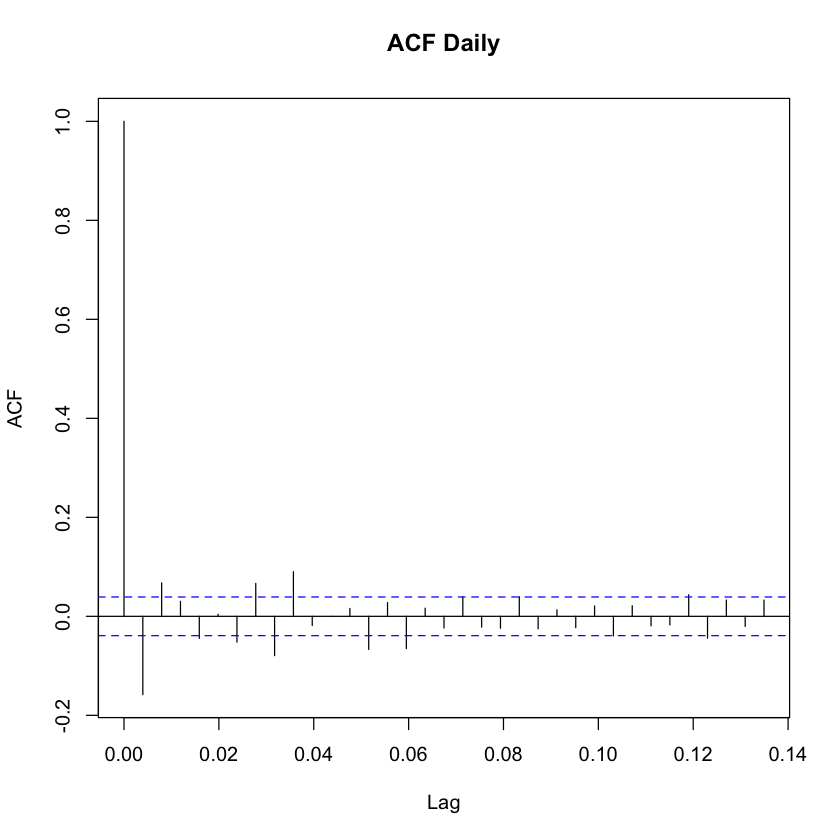

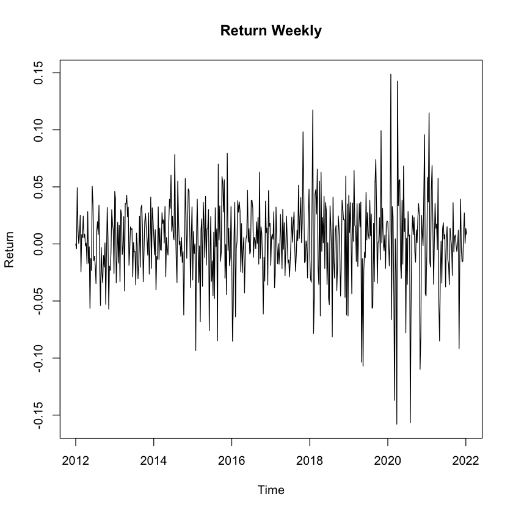

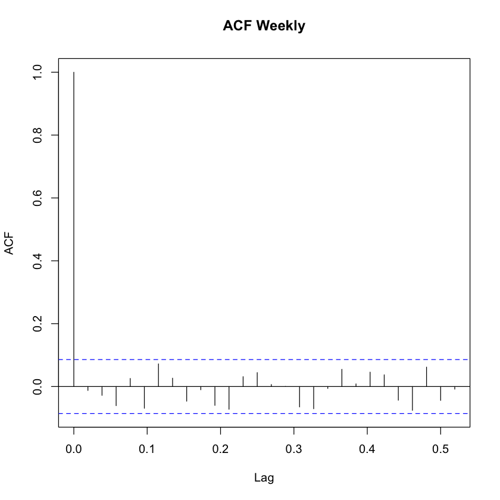

```r
# Calculate return of daily
returnDaily <- diff(INTDaily) / INTDaily[- length(INTDaily)]
returnDaily <- c(0,returnDaily)
returnDaily.ts <- ts(returnDaily, start = c(2012, 1, 1), frequency = 252)

plot.ts(returnDaily.ts, main="Return Daily", ylab="Return")
acf(returnDaily.ts, main="ACF Daily")

#Calculate return of weekly
returnWeekly <- diff(INTWeekly) / INTWeekly[- length(INTWeekly)]
returnWeekly <- c(0,returnWeekly)
returnWeekly.ts <- ts(returnWeekly, start = c(2012, 1, 1), frequency = 52)

plot.ts(returnWeekly.ts, main="Return Weekly", ylab="Return")
acf(returnWeekly.ts, main="ACF Weekly")
```

*Response: Question 1d*

Both datasets show some cyclic pattern. The daily datasets exhibits some ACF lags outside the confidence bands. However the weekly dataset shows a weakly stationary process because no lags are outside the confidence bands.

# Question 2: ARIMA(p,d,q) for Stock Price (20 Points)

**2a.** Divide the data into training and testing data set, where the training data exclude the last week of data (December 27th - December 30th) with the testing data including the last week of data. Apply the iterative model to fit an ARIMA(p,d,q) model with max AR and MA orders of 8 and difference orders 1 and 2 separately to the training datasets of the daily and weekly data. Display the summary of the final model fit.

```r
# Create ARIMA fit function

arimafitfunction <- function(datatrain, norderpq, norderd) {

p = c(1:norderpq)-1; q = c(1:norderpq)-1; d = c(1:norderd)

aic1 = matrix(0, norderpq, norderpq)
aic2 = matrix(0, norderpq, norderpq)

for (i in 1:norderpq){
    for (j in 1:norderpq){
        for (k in 1:norderd){
            modijk = arima(datatrain$Adj.Close, order = c(p[i], d[k], q[j]), method = 'ML')
            if (k == 1){
                aic1[i,j] = modijk$aic-2*(p[i]+q[j]+1)+2*(p[i]+q[j]+1)*length(daily.w.train)/(length(daily.w.train)-p[i]-q[j]-2)
            } else {
                aic2[i,j] = modijk$aic-2*(p[i]+q[j]+1)+2*(p[i]+q[j]+1)*length(daily.w.train)/(length(daily.w.train)-p[i]-q[j]-2)
            }
        }
    }
}

aicv1 = as.vector(aic1)
indexp1 = rep(c(1:norderpq),norderpq)
indexq1 = rep(c(1:norderpq),each=norderpq)
indexaic1 = which(aicv1 == min(aicv1))
porder1 = indexp1[indexaic1]-1
qorder1 = indexq1[indexaic1]-1

minaic1 = aic1[porder1+1,qorder1+1]

aicv2 = as.vector(aic2)
indexp2 = rep(c(1:norderpq),norderpq)
indexq2 = rep(c(1:norderpq),each=norderpq)
indexaic2 = which(aicv2 == min(aicv2))
porder2 = indexp2[indexaic2]-1
qorder2 = indexq2[indexaic2]-1

minaic2 = aic1[porder2+1,qorder2+1]

if (minaic1 < minaic2){
    arima = arima(datatrain$Adj.Close, order = c(porder1, 1, qorder1), method = 'ML')
    d = 1
    p = porder1
    q = qorder1
} else {
    arima = arima(datatrain$Adj.Close, order = c(porder2, 2, qorder2), method = 'ML')
    d = 2
    p = porder2
    q = qorder2
}

 return(list(arima=arima, p=p, q=q, d=d))
}
```

```r
options(warn = -1)
numdaily <- 4
numweekly <- 1
# set up the training and testing data
daily.w.train <- head(dailydata, n=length(dailydata$Date)-numdaily)
daily.w.test <-tail(dailydata, n=numdaily)
weekly.w.train <- head(weeklydata, n=length(weeklydata$Date)-numweekly)
weekly.w.test <- tail(weeklydata, n=numweekly)
```

```r
arima.daily = arimafitfunction(daily.w.train, 8, 2)
arima.daily$arima
```

```
Call:
arima(x = datatrain$Adj.Close, order = c(porder1, 1, qorder1), method = "ML")

Coefficients:
          ar1     ar2     ar3      ar4      ar5     ar6     ar7    ma1      ma2
      -0.5843  0.2644  0.4196  -0.1513  -0.0796  0.4091  0.5718  0.428  -0.2667
s.e.   0.1416  0.1997  0.1053   0.1641   0.1389  0.0963  0.0821  0.143   0.1796
          ma3     ma4      ma5      ma6      ma7
      -0.2803  0.1777  -0.0217  -0.4834  -0.4819
s.e.   0.0955  0.1363   0.1156   0.0922   0.0936

sigma^2 estimated as 0.5793:  log likelihood = -2877.86,  aic = 5785.72
```

```r
arima.weekly = arimafitfunction(weekly.w.train, 8, 2)
arima.weekly$arima
```

```
Call:
arima(x = datatrain$Adj.Close, order = c(porder1, 1, qorder1), method = "ML")

Coefficients:
          ar1      ar2     ar3      ar4     ar5     ar6     ar7      ma1
      -0.0052  -0.4225  0.2174  -0.4373  0.3024  0.3518  0.3817  -0.0139
s.e.   0.2229   0.3077  0.2026   0.1361  0.2277  0.2852     NaN   0.2059
         ma2      ma3     ma4      ma5      ma6      ma7
      0.4102  -0.2529  0.4601  -0.4826  -0.3479  -0.4352
s.e.  0.3213   0.1975  0.1308   0.2375   0.3424      NaN

sigma^2 estimated as 2.17:  log likelihood = -941.71,  aic = 1913.43
```

**2b.** Evaluate the model residuals and squared residuals using the ACF and PACF plots as well as hypothesis testing for serial correlation. What would you conclude based on this analysis?

```
	Box-Pierce test

data:  arima.daily$arima$resid
X-squared = 3.8337, df = 1, p-value = 0.05023
```

```
	Box-Ljung test

data:  arima.daily$arima$resid
X-squared = 3.8512, df = 1, p-value = 0.04971
```

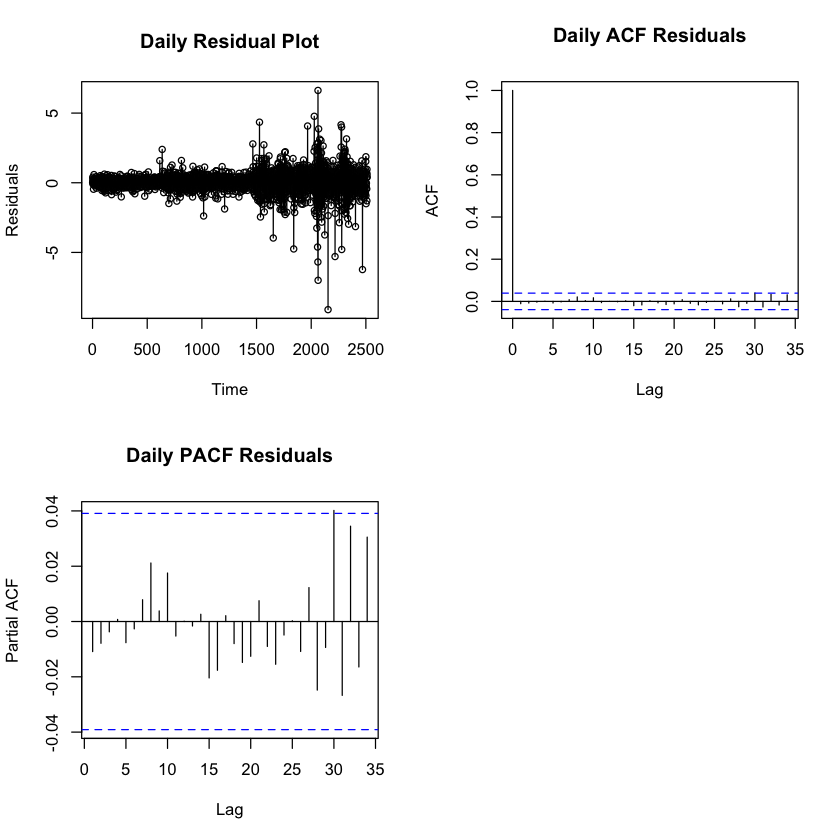

```r
par(mfrow = c(2, 2))
plot(arima.daily$arima$resid, ylab="Residuals", type = "o", main = "Daily Residual Plot")
acf(arima.daily$arima$resid, main = "Daily ACF Residuals")
pacf(arima.daily$arima$resid, main = "Daily PACF Residuals")

Box.test(arima.daily$arima$resid, lag = (arima.daily$p+arima.daily$q+1), type="Box-Pierce", fitdf=(arima.daily$p+arima.daily$q))
Box.test(arima.daily$arima$resid, lag = (arima.daily$p+arima.daily$q+1), type="Ljung-Box", fitdf=(arima.daily$p+arima.daily$q))
```

```
	Box-Pierce test

data:  arima.weekly$arima$resid
X-squared = 5.077, df = 1, p-value = 0.02424
```

```
	Box-Ljung test

data:  arima.weekly$arima$resid
X-squared = 5.1979, df = 1, p-value = 0.02261
```

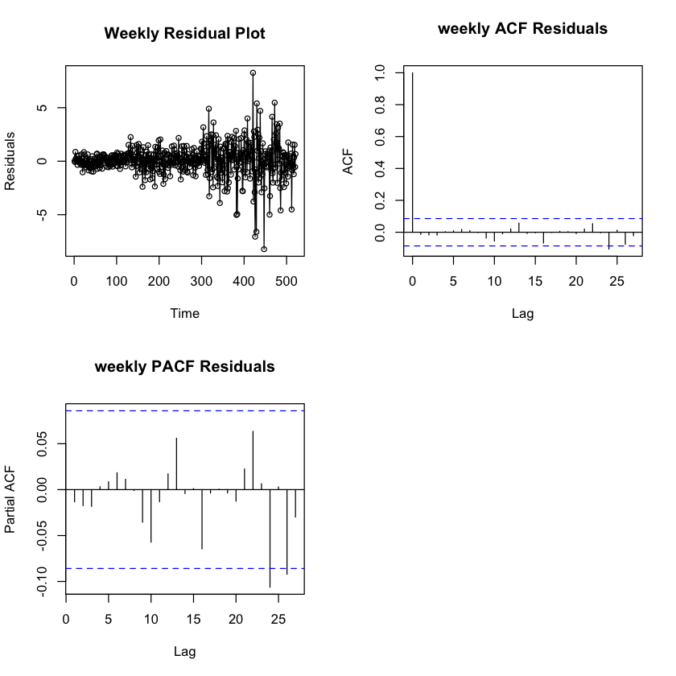

```r
par(mfrow = c(2, 2))
plot(arima.weekly$arima$resid, ylab="Residuals", type = "o", main = "Weekly Residual Plot")
acf(arima.weekly$arima$resid, main = "weekly ACF Residuals")
pacf(arima.weekly$arima$resid, main = "weekly PACF Residuals")

Box.test(arima.weekly$arima$resid, lag = (arima.weekly$p+arima.weekly$q+1), type="Box-Pierce", fitdf=(arima.weekly$p+arima.weekly$q))
Box.test(arima.weekly$arima$resid, lag = (arima.weekly$p+arima.weekly$q+1), type="Ljung-Box", fitdf=(arima.weekly$p+arima.weekly$q))
```

**2c.** Apply the model identified in (2a) and forecast the last week of data. Plot the predicted data to compare the predicted values to the actual observed ones. Include 95% confidence intervals for the forecasts in the corresponding plots.

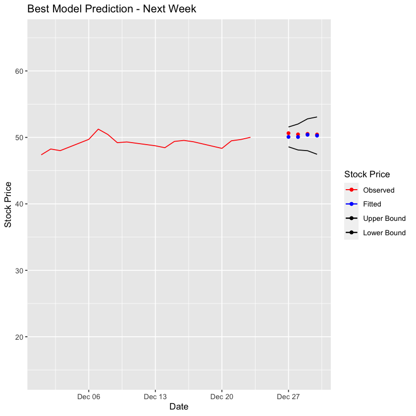

```r
# Daily Data
outpred.daily <- predict(arima.daily$arima, n.ahead = 4) # 95% confidence interval
ubound.daily <- outpred.daily$pred + 1.96 * outpred.daily$se
lbound.daily <- outpred.daily$pred - 1.96 * outpred.daily$se
ggplot() +
  geom_line(data = daily.w.train, aes(x = Date, y = Adj.Close, color="Observed")) +
  geom_point(data = daily.w.test, aes(x = Date, y = Adj.Close, color = "Observed")) +
  geom_point(data = daily.w.test, aes(x = Date, y = outpred.daily$pred, color = "Fitted")) +
  geom_line(data = daily.w.test, aes(x = Date, y = ubound.daily, color="Upper Bound")) +
  geom_line(data = daily.w.test, aes(x = Date, y = lbound.daily, color="Lower Bound")) +
  xlab('Date') + xlim(as.Date(c('2021-12-01',max(dailydata$Date)))) +
  ylab('Stock Price') + labs(title = 'Best Model Prediction - Next Week') + scale_color_manual(name='Stock Price',
                     breaks=c('Observed', 'Fitted', 'Upper Bound', 'Lower Bound'),
                     values=c('Observed'='red', 'Fitted'='blue', 'Upper Bound' = 'black', 'Lower Bound'='black'))
```

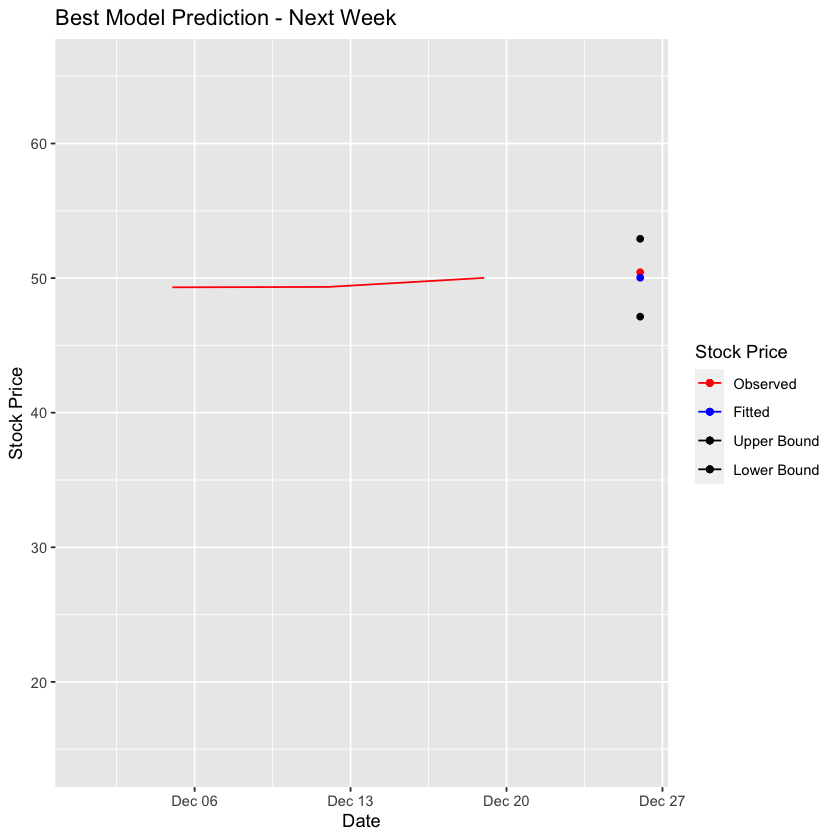

```r
# Weekly Data
outpred.weekly <- predict(arima.weekly$arima, n.ahead = 1) # 90% confidence interval
ubound.weekly <- outpred.weekly$pred + 1.96 * outpred.weekly$se
lbound.weekly <- outpred.weekly$pred - 1.96 * outpred.weekly$se
ggplot() +
  geom_line(data = weekly.w.train, aes(x = Date, y = Adj.Close, color="Observed")) +
  geom_point(data = weekly.w.test, aes(x = Date, y = Adj.Close, color = "Observed")) +
  geom_point(data = weekly.w.test, aes(x = Date, y = outpred.weekly$pred, color = "Fitted")) +
  geom_point(data = weekly.w.test, aes(x = Date, y = ubound.weekly, color="Upper Bound")) +
  geom_point(data = weekly.w.test, aes(x = Date, y = lbound.weekly, color="Lower Bound")) +
  xlab('Date') + xlim(as.Date(c('2021-12-01',max(weeklydata$Date)))) +
  ylab('Stock Price') + labs(title = 'Best Model Prediction - Next Week') + scale_color_manual(name='Stock Price',
                     breaks=c('Observed', 'Fitted', 'Upper Bound', 'Lower Bound'),
                     values=c('Observed'='red', 'Fitted'='blue', 'Upper Bound' = 'black', 'Lower Bound'='black'))
```

**2d.** Calculate Mean Absolute Percentage Error (MAPE) and Precision Measure (PM) (PM only for daily data). How many observations are within the prediction bands? Compare the accuracy of the predictions for the daily and weekly time series using these two measures.

```r
# Daily
## MAPE
MAPE.Daily = mean(abs(outpred.daily$pred-daily.w.test$Adj.Close)/daily.w.test$Adj.Close)
paste("The MAPE of the daily prediction is:", round(MAPE.Daily, 3))
## PM
PM.Daily = sum((outpred.daily$pred-daily.w.test$Adj.Close)^2)/sum((daily.w.test$Adj.Close-mean(daily.w.test$Adj.Close))^2)
paste("The PM of the daily prediction is:", round(PM.Daily, 3))
```

'The MAPE of the daily prediction is: 0.006'

'The PM of the daily prediction is: 21.898'

```r
# Weekly
## MAPE
MAPE.weekly = mean(abs(outpred.weekly$pred-weekly.w.test$Adj.Close)/weekly.w.test$Adj.Close)
paste("The MAPE of the weekly prediction is:", round(MAPE.weekly, 3))
## PM
PM.weekly = sum((outpred.weekly$pred-weekly.w.test$Adj.Close)^2)/sum((weekly.w.test$Adj.Close-mean(weekly.w.test$Adj.Close))^2)
paste("The PM of the weekly prediction is:", round(PM.weekly, 3))
```

'The MAPE of the weekly prediction is: 0.008'

'The PM of the weekly prediction is: Inf'

The instructions stated to only predict the last week. The resulting forecast for the daily dataset is 4 days. However there is only 1 data point for the weekly data. The results are difficult to compare for this reason. The PM metric always be infinite becasue the mean of one number is the same number, resulting in 0 in the denomerator of the PM metric.

For what its worth the MAPE value is lower for the daily data indicating this model fits the model better.

# Question 3: ARMA(p,q)-GARCH(m,n) for Return Stock Price (20 Points)

**3a.** Divide the data into training and testing data set, where the training data exclude the last week of data (December 27th - December 30th) with the testing data including the last week of data. Apply the iterative model to fit an ARMA(p,q)-GARCH(m,n) model by selecting the orders for p & q up to 5 and orders for m & n up to 2. Display the summary of the final model fit. Write up the equation of the estimated model.

```r
# Divide data into daily and weekly train and test

numdaily <- 4
numweekly <- 1
# set up the training and testing data
daily.w.train <- head(dailydata, n=length(dailydata$Date)-numdaily)
daily.w.test <-tail(dailydata, n=numdaily)
weekly.w.train <- head(weeklydata, n=length(weeklydata$Date)-numweekly)
weekly.w.test <- tail(weeklydata, n=numweekly)

# Fit garch using fixed arma model

test_modelAGG <- function(data,m,n){
    spec = ugarchspec(variance.model=list(garchOrder=c(m,n)),
                      mean.model=list(armaOrder=c(5,5),
                                      include.mean=T),
                      distribution.model="std")
    fit = ugarchfit(spec, data, solver = 'hybrid')
    current.bic = infocriteria(fit)[2]
    df = data.frame(m,n,current.bic)
    names(df) <- c("m","n","BIC")
    print(paste(m,n,current.bic,sep=" "))
    return(df)
}

#Daily

ordersAGG.daily = data.frame(Inf,Inf,Inf)
names(ordersAGG.daily) <- c("m","n","BIC")

for (m in 0:2){
    for (n in 0:2){
        possibleError <- tryCatch(
            ordersAGG.daily<-rbind(ordersAGG.daily,test_modelAGG(daily.w.train$Adj.Close,m,n)),
            error=function(e) e
        )
        if(inherits(possibleError, "error")) next
    }
}
ordersAGG.daily <- ordersAGG.daily[order(-ordersAGG.daily$BIC),]
print("Daily")
tail(ordersAGG.daily)

#Weekly

ordersAGG.weekly = data.frame(Inf,Inf,Inf)
names(ordersAGG.weekly) <- c("m","n","BIC")

for (m in 0:2){
    for (n in 0:2){
        possibleError <- tryCatch(
            ordersAGG.weekly<-rbind(ordersAGG.weekly,test_modelAGG(weekly.w.train$Adj.Close,m,n)),
            error=function(e) e
        )
        if(inherits(possibleError, "error")) next
    }
}
ordersAGG.weekly <- ordersAGG.weekly[order(-ordersAGG.daily$BIC),]
print("Weekly")
tail(ordersAGG.weekly)
```

```
[1] "0 0 1.72094543291288"
[1] "0 1 1.61280964192549"
[1] "0 2 1.59185836980609"
[1] "1 0 1.57435899652589"
[1] "1 1 1.40115095867256"
[1] "1 2 1.40228707994689"
[1] "2 0 1.51613389491883"
[1] "2 1 1.40200706152546"
[1] "2 2 1.4054061050508"
[1] "Daily"
```

A data.frame: 6 × 3

|  | m <dbl> | n <dbl> | BIC <dbl> |
| --- | --- | --- | --- |
| 5 | 1 | 0 | 1.574359 |
| 8 | 2 | 0 | 1.516134 |
| 10 | 2 | 2 | 1.405406 |
| 7 | 1 | 2 | 1.402287 |
| 9 | 2 | 1 | 1.402007 |
| 6 | 1 | 1 | 1.401151 |

```
[1] "0 0 3.39823197607348"
[1] "0 1 3.23762039712586"
[1] "0 2 3.24653016351972"
[1] "1 0 3.31485018548616"
[1] "1 1 3.17886206820231"
[1] "1 2 3.19035411205921"
[1] "2 0 3.27241436186154"
[1] "2 1 3.19086926810932"
[1] "2 2 3.20222803441103"
[1] "Weekly"
```

A data.frame: 6 × 3

|  | m <dbl> | n <dbl> | BIC <dbl> |
| --- | --- | --- | --- |
| 5 | 1 | 0 | 3.314850 |
| 6 | 1 | 1 | 3.178862 |
| 7 | 1 | 2 | 3.190354 |
| 8 | 2 | 0 | 3.272414 |
| 9 | 2 | 1 | 3.190869 |
| 10 | 2 | 2 | 3.202228 |

```r
#ARMA update
#ARIMA-GARCH: Select ARIMA order
test_modelAGA <- function(data,p,q){
    spec = ugarchspec(variance.model=list(garchOrder=c(1,1)),
                      mean.model=list(armaOrder=c(p,q),
                                      include.mean=T),
                      distribution.model="std")
    fit = ugarchfit(spec, data, solver = 'hybrid')
    current.bic = infocriteria(fit)[2]
    df = data.frame(p,q,current.bic)
    names(df) <- c("p","q","BIC")
    print(paste(p,q,current.bic,sep=" "))
    return(df)
}

#Daily

ordersAGA.daily = data.frame(Inf,Inf,Inf)
names(ordersAGA.daily) <- c("p","q","BIC")
for (p in 0:5){
    for (q in 0:5){
        possibleError <- tryCatch(
            ordersAGA.daily<-rbind(ordersAGA.daily,test_modelAGA(daily.w.train$Adj.Close,p,q)),
            error=function(e) e
        )
        if(inherits(possibleError, "error")) next
    }
}
ordersAGA.daily <- ordersAGA.daily[order(-ordersAGA.daily$BIC),]
tail(ordersAGA.daily)

#Weekly

ordersAGA.weekly = data.frame(Inf,Inf,Inf)
names(ordersAGA.weekly) <- c("p","q","BIC")
for (p in 0:5){
    for (q in 0:5){
        possibleError <- tryCatch(
            ordersAGA.weekly<-rbind(ordersAGA.weekly,test_modelAGA(weekly.w.train$Adj.Close,p,q)),
            error=function(e) e
        )
        if(inherits(possibleError, "error")) next
    }
}
ordersAGA.weekly <- ordersAGA.weekly[order(-ordersAGA.weekly$BIC),]
tail(ordersAGA.weekly)
```

```
[1] "0 0 6.86203078264402"
[1] "0 1 5.75253330727302"
[1] "0 2 4.91929461848626"
[1] "0 3 4.28672065378463"
[1] "0 4 3.85319244735943"
[1] "0 5 3.47892539303506"
[1] "1 0 1.37792195543102"
[1] "1 1 1.38034228844073"
[1] "1 2 1.38348059660009"
[1] "1 3 1.38690738420753"
[1] "1 4 1.3905093398829"
[1] "1 5 1.39346146783363"
[1] "2 0 1.37800599182837"
[1] "2 1 1.38100294003319"
[1] "2 2 1.38387032165001"
```

[output cut: 21 more lines]

A data.frame: 6 × 3

|  | p <dbl> | q <dbl> | BIC <dbl> |
| --- | --- | --- | --- |
| 21 | 3 | 1 | 1.382550 |
| 20 | 3 | 0 | 1.381484 |
| 15 | 2 | 1 | 1.381003 |
| 9 | 1 | 1 | 1.380342 |
| 14 | 2 | 0 | 1.378006 |
| 8 | 1 | 0 | 1.377922 |

```
[1] "0 0 7.0172509351445"
[1] "0 1 6.08553521762103"
[1] "0 2 5.32190061519006"
[1] "0 3 4.93894255835785"
[1] "0 4 4.59144233934841"
[1] "0 5 4.36272270985847"
[1] "1 0 3.09026092013131"
[1] "1 1 3.10214446775289"
[1] "1 2 3.11611789845009"
[1] "1 3 3.12592309740069"
[1] "1 4 3.13746940951346"
[1] "1 5 3.15087003991026"
[1] "2 0 3.10152815704515"
[1] "2 1 3.10876637822787"
[1] "2 2 3.12122333363717"
```

[output cut: 21 more lines]

A data.frame: 6 × 3

|  | p <dbl> | q <dbl> | BIC <dbl> |
| --- | --- | --- | --- |
| 10 | 1 | 2 | 3.116118 |
| 20 | 3 | 0 | 3.114337 |
| 15 | 2 | 1 | 3.108766 |
| 9 | 1 | 1 | 3.102144 |
| 14 | 2 | 0 | 3.101528 |
| 8 | 1 | 0 | 3.090261 |

```r
#GARCH update
test_modelAGG <- function(data,m,n){
    spec = ugarchspec(variance.model=list(garchOrder=c(m,n)),
                      mean.model=list(armaOrder=c(1,0),
                                      include.mean=T), distribution.model="std")
    fit = ugarchfit(spec, data, solver = 'hybrid')
    current.bic = infocriteria(fit)[2]
    df = data.frame(m,n,current.bic)
    names(df) <- c("m","n","BIC")
    print(paste(m,n,current.bic,sep=" "))
    return(df)
}

#Daily

ordersAGG.daily = data.frame(Inf,Inf,Inf)
names(ordersAGG.daily) <- c("m","n","BIC")

for (m in 0:2){
    for (n in 0:2){
        possibleError <- tryCatch(
            ordersAGG.daily<-rbind(ordersAGG.daily,test_modelAGG(daily.w.train$Adj.Close,m,n)),
            error=function(e) e
        )
        if(inherits(possibleError, "error")) next
    }
}
ordersAGG.daily <- ordersAGG.daily[order(-ordersAGG.daily$BIC),]
tail(ordersAGG.daily)
# Final Daily ARMA(1,0)+GARCH(1,1) selected

#Weekly

ordersAGG.weekly = data.frame(Inf,Inf,Inf)
names(ordersAGG.weekly) <- c("m","n","BIC")

for (m in 0:2){
    for (n in 0:2){
        possibleError <- tryCatch(
            ordersAGG.weekly<-rbind(ordersAGG.weekly,test_modelAGG(weekly.w.train$Adj.Close,m,n)),
            error=function(e) e
        )
        if(inherits(possibleError, "error")) next
    }
}
ordersAGG.weekly <- ordersAGG.weekly[order(-ordersAGG.weekly$BIC),]
tail(ordersAGG.weekly)
# Final Weekly ARMA(1,0)+GARCH(1,1) selected
```

```
[1] "0 0 1.70924658730058"
[1] "0 1 1.60017690088139"
[1] "0 2 1.57847033340932"
[1] "1 0 1.57961646055123"
[1] "1 1 1.37792195543102"
[1] "1 2 1.37933590755965"
[1] "2 0 1.51566515933416"
[1] "2 1 1.38155822062379"
[1] "2 2 1.38245252980259"
```

A data.frame: 6 × 3

|  | m <dbl> | n <dbl> | BIC <dbl> |
| --- | --- | --- | --- |
| 4 | 0 | 2 | 1.578470 |
| 8 | 2 | 0 | 1.515665 |
| 10 | 2 | 2 | 1.382453 |
| 9 | 2 | 1 | 1.381558 |
| 7 | 1 | 2 | 1.379336 |
| 6 | 1 | 1 | 1.377922 |

```
[1] "0 0 3.34349953371077"
[1] "0 1 3.18970652473023"
[1] "0 2 3.19648614627608"
[1] "1 0 3.26492277224364"
[1] "1 1 3.09026092013131"
[1] "1 2 3.1043697073077"
[1] "2 0 3.22474696028141"
[1] "2 1 3.10448394014299"
[1] "2 2 3.11532268974925"
```

A data.frame: 6 × 3

|  | m <dbl> | n <dbl> | BIC <dbl> |
| --- | --- | --- | --- |
| 4 | 0 | 2 | 3.196486 |
| 3 | 0 | 1 | 3.189707 |
| 10 | 2 | 2 | 3.115323 |
| 9 | 2 | 1 | 3.104484 |
| 7 | 1 | 2 | 3.104370 |
| 6 | 1 | 1 | 3.090261 |

```r
# Same model chosen for daily and weekly data
spec = ugarchspec(variance.model=list(garchOrder=c(1,1)),
                 mean.model=list(armaOrder=c(1, 0),
                 include.mean=T), distribution.model="std")
garch.arma.model.daily = ugarchfit(spec, daily.w.train$Adj.Close, solver = 'hybrid')
garch.arma.model.weekly = ugarchfit(spec, weekly.w.train$Adj.Close, solver = 'hybrid')

garch.arma.model.daily

garch.arma.model.weekly
```

```
*---------------------------------*
*          GARCH Model Fit        *
*---------------------------------*

Conditional Variance Dynamics
-----------------------------------
GARCH Model	: sGARCH(1,1)
Mean Model	: ARFIMA(1,0,0)
Distribution	: std

Optimal Parameters
------------------------------------
        Estimate  Std. Error   t value Pr(>|t|)
mu     17.825629    0.394142   45.2264 0.000000
ar1     1.000000    0.000602 1659.7640 0.000000
omega   0.001375    0.000503    2.7309 0.006315
alpha1  0.057622    0.010251    5.6212 0.000000
beta1   0.941378    0.010242   91.9116 0.000000
shape   3.768611    0.280573   13.4318 0.000000

Robust Standard Errors:
        Estimate  Std. Error   t value Pr(>|t|)
mu     17.825629    0.039025  456.7795 0.000000
ar1     1.000000    0.000649 1540.0631 0.000000
omega   0.001375    0.000747    1.8409 0.065631
alpha1  0.057622    0.020839    2.7651 0.005690
beta1   0.941378    0.021403   43.9827 0.000000
shape   3.768611    0.387962    9.7139 0.000000

LogLikelihood : -1707.183

Information Criteria
------------------------------------

Akaike       1.3640
Bayes        1.3779
Shibata      1.3640
Hannan-Quinn 1.3691

Weighted Ljung-Box Test on Standardized Residuals
```

[output cut: 42 more lines]

```
Negative Sign Bias 1.03942 0.2987
Positive Sign Bias 1.54907 0.1215
Joint Effect       3.56133 0.3129


Adjusted Pearson Goodness-of-Fit Test:
------------------------------------
  group statistic p-value(g-1)
1    20     26.68      0.11237
2    30     42.35      0.05225
3    40     53.38      0.06225
4    50     56.87      0.20539


Elapsed time : 0.345876
```

```
*---------------------------------*
*          GARCH Model Fit        *
*---------------------------------*

Conditional Variance Dynamics
-----------------------------------
GARCH Model	: sGARCH(1,1)
Mean Model	: ARFIMA(1,0,0)
Distribution	: std

Optimal Parameters
------------------------------------
        Estimate  Std. Error  t value Pr(>|t|)
mu     18.341401    0.832122  22.0417 0.000000
ar1     1.000000    0.003287 304.2026 0.000000
omega   0.016059    0.009483   1.6934 0.090386
alpha1  0.105714    0.025910   4.0801 0.000045
beta1   0.893285    0.024190  36.9274 0.000000
shape   4.580773    0.906315   5.0543 0.000000

Robust Standard Errors:
        Estimate  Std. Error  t value Pr(>|t|)
mu     18.341401    0.132308 138.6270 0.000000
ar1     1.000000    0.003274 305.4045 0.000000
omega   0.016059    0.010217   1.5717 0.116018
alpha1  0.105714    0.026410   4.0028 0.000063
beta1   0.893285    0.026044  34.2994 0.000000
shape   4.580773    1.097470   4.1739 0.000030

LogLikelihood : -786.2457

Information Criteria
------------------------------------

Akaike       3.0413
Bayes        3.0903
Shibata      3.0410
Hannan-Quinn 3.0604

Weighted Ljung-Box Test on Standardized Residuals
```

[output cut: 42 more lines]

```
Negative Sign Bias  0.1092 0.9130
Positive Sign Bias  0.1764 0.8600
Joint Effect        0.8662 0.8336


Adjusted Pearson Goodness-of-Fit Test:
------------------------------------
  group statistic p-value(g-1)
1    20     33.28      0.02231
2    30     44.05      0.03632
3    40     50.44      0.10373
4    50     61.63      0.10634


Elapsed time : 0.102982
```

**3b.** Evaluate the model residuals and squared residuals using the ACF and PACF plots as well as hypothesis testing for serial correlation. What would you conclude based on this analysis?

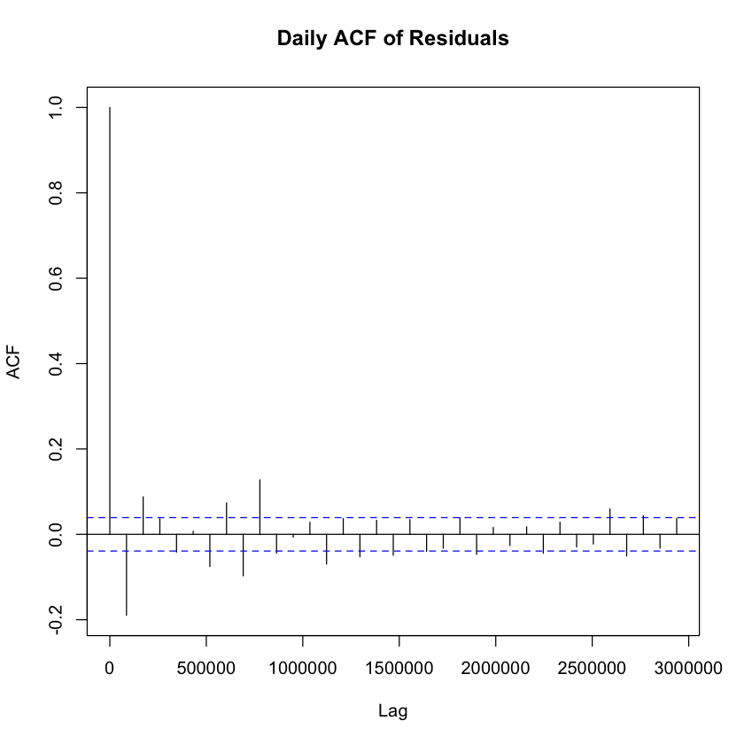

```
	Box-Ljung test

data:  garch.arma.model.daily.residuals
X-squared = 215.6, df = 10, p-value < 2.2e-16
```

```
	Box-Ljung test

data:  garch.arma.model.daily.residuals^2
X-squared = 877.87, df = 10, p-value < 2.2e-16
```

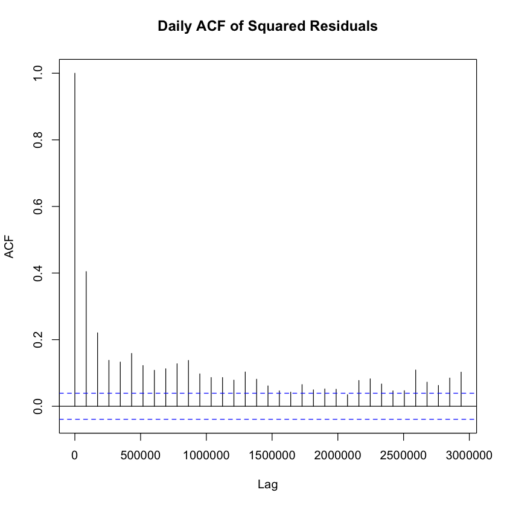

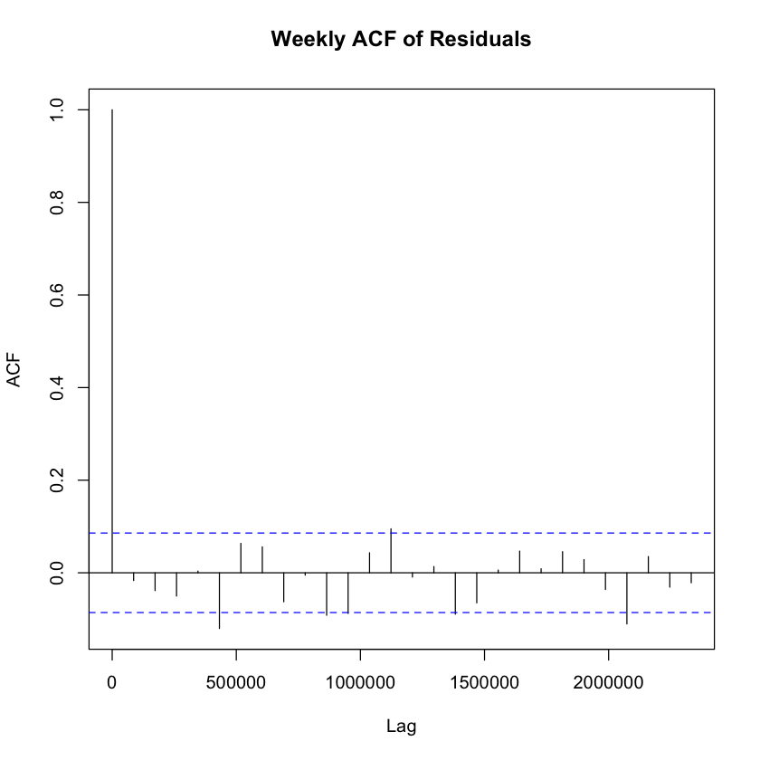

```
	Box-Ljung test

data:  garch.arma.model.weekly.residuals
X-squared = 20.294, df = 10, p-value = 0.02659
```

```
	Box-Ljung test

data:  garch.arma.model.weekly.residuals^2
X-squared = 112.52, df = 10, p-value < 2.2e-16
```

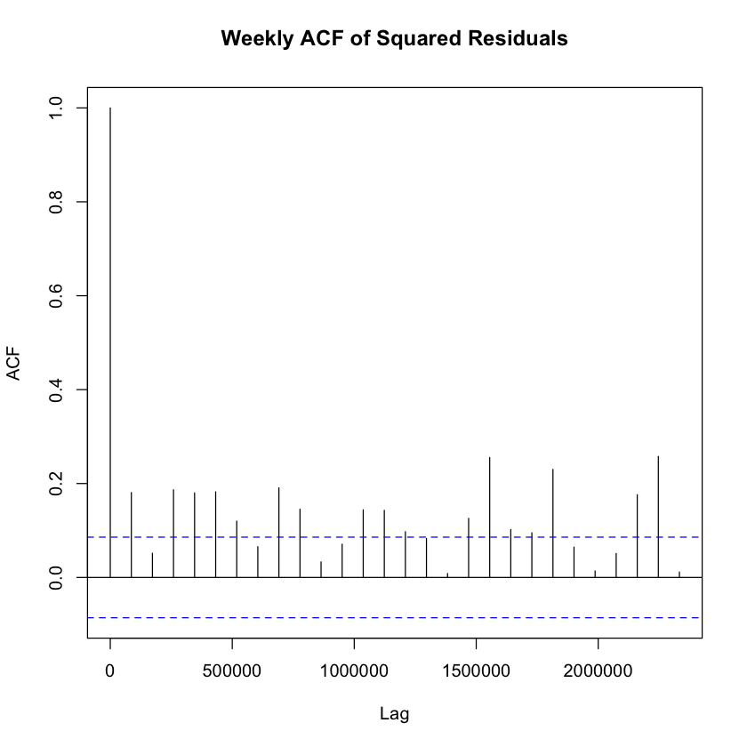

```r
#Daily
garch.arma.model.daily.residuals = residuals(garch.arma.model.daily)
acf(garch.arma.model.daily.residuals,main="Daily ACF of Residuals")
acf(garch.arma.model.daily.residuals^2,main="Daily ACF of Squared Residuals")
Box.test(garch.arma.model.daily.residuals,lag=10,type='Ljung')
Box.test(garch.arma.model.daily.residuals^2,lag=10,type='Ljung')

#Weekly
garch.arma.model.weekly.residuals = residuals(garch.arma.model.weekly)
acf(garch.arma.model.weekly.residuals,main="Weekly ACF of Residuals")
acf(garch.arma.model.weekly.residuals^2,main="Weekly ACF of Squared Residuals")
Box.test(garch.arma.model.weekly.residuals,lag=10,type='Ljung')
Box.test(garch.arma.model.weekly.residuals^2,lag=10,type='Ljung')
```

*Response: Question 3b*

Both the residuals and squared residuals for both daily and weekly model serial correlation results are less than 0.05 indicating we reject the null hypothesis that the data is not serial correlated. Further the the ACF plots of the squared residuals are greater than the confidence bands for most lags showing non-stationarity. The ACF plot of the residuals is closer to a white noise process but still has large ACF for some lags.

**3c.** Apply the model identified in (3a) and forecast the mean and the variance of the last week of data. Plot the predicted data to compare the predicted values to the actual observed ones. Interpret the results, particularly comparing forecast using daily versus weekly data.

1.36471549648552

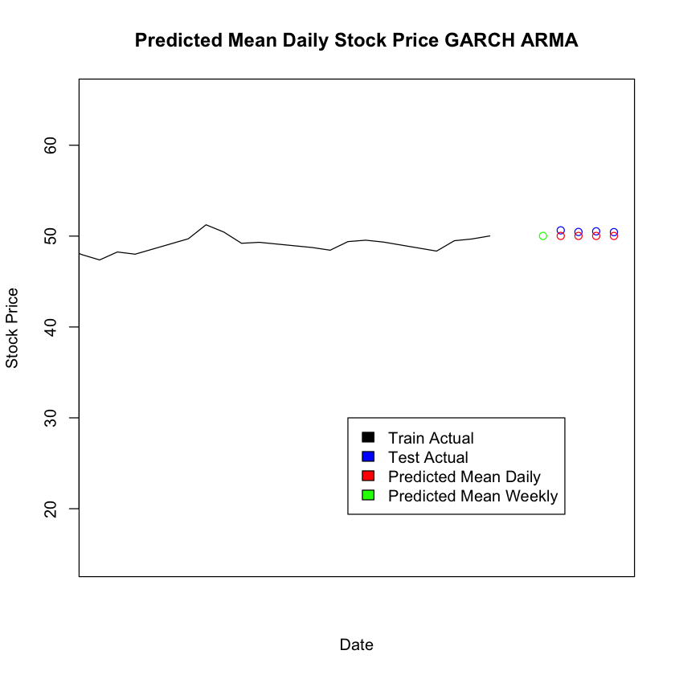

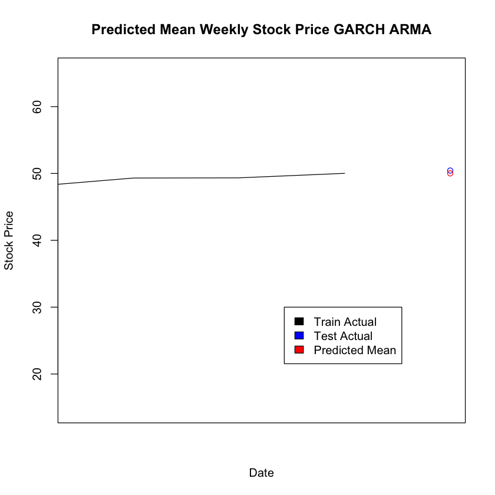

```r
fore.daily = ugarchforecast(garch.arma.model.daily, n.ahead=4)
fore.daily.series = NULL
fore.daily.sigma = NULL
fore.daily.series = c(fore.daily.series, fore.daily@forecast$seriesFor)
fore.daily.sigma = c(fore.daily.sigma, fore.daily@forecast$sigmaFor)

data.plot.daily = daily.w.test
names(data.plot.daily$Adj.Close)="Fore"
data.plot.daily$ForeSeries = fore.daily.series
data.plot.daily$ForeSigma = fore.daily.sigma

plot(x = daily.w.train$Date,
     y = daily.w.train$Adj.Close,
     type = "l",
     xlim=c(date("2021-12-1"), max(daily.w.test$Date)),
     ylab="Stock Price",
     xlab="Date",
     main="Predicted Mean Daily Stock Price GARCH ARMA"
    )
points(x = daily.w.test$Date, y = daily.w.test$Adj.Close, col="blue")
points(x=data.plot.daily$Date, data.plot.daily$ForeSeries, col="red")
points(x=data.plot.weekly$Date, data.plot.weekly$ForeSeries, col="green")
legend(date("2021-12-15"), 30,legend=c("Train Actual", "Test Actual", "Predicted Mean Daily", "Predicted Mean Weekly"),
       fill = c("black", "blue","red", "green")
)

fore.weekly = ugarchforecast(garch.arma.model.weekly, n.ahead=1)
fore.weekly.series = NULL
fore.weekly.sigma = NULL
fore.weekly.series = c(fore.weekly.series, fore.weekly@forecast$seriesFor)
fore.weekly.sigma = c(fore.weekly.sigma, fore.weekly@forecast$sigmaFor)

fore.weekly.sigma

data.plot.weekly = weekly.w.test
names(data.plot.weekly$Adj.Close)="Fore"
data.plot.weekly$ForeSeries = fore.weekly.series
data.plot.weekly$ForeSigma = fore.weekly.sigma

plot(x = weekly.w.train$Date,
     y = weekly.w.train$Adj.Close,
     type = "l",
     xlim=c(date("2021-12-1"), max(weekly.w.test$Date)),
     ylab="Stock Price",
     xlab="Date",
     main="Predicted Mean Weekly Stock Price GARCH ARMA"
    )
points(x = weekly.w.test$Date, y = weekly.w.test$Adj.Close, col="blue")
points(x=data.plot.weekly$Date, data.plot.weekly$ForeSeries, col="red")
legend(date("2021-12-15"), 30,legend=c("Train Actual", "Test Actual", "Predicted Mean"),
       fill = c("black", "blue","red")
)
```

*Response: Question 3c*

Overall, the forecast is very close to the actual values. The daily predictions is consitently lower than the actual data. When comparing the daily to weekly predictions, the The predictions are very close. This is expected because the chosen orders for the GARCH ARMA joint model orders are the same for the daily and weekly models.

**3d.** Calculate Mean Absolute Percentage Error (MAPE) and Precision Measure (PM) for the mean forecasts (PM should net be calculated for weekly data). Compare the accuracy of the predictions for the daily and weekly time series using these two measures.

```r
# Daily
## MAPE
MAPE.Daily = mean(abs(data.plot.daily$ForeSeries-daily.w.test$Adj.Close)/daily.w.test$Adj.Close)
paste("The MAPE of the daily prediction is:", round(MAPE.Daily, 3))
## PM
PM.Daily = sum((data.plot.daily$ForeSeries-daily.w.test$Adj.Close)^2)/sum((daily.w.test$Adj.Close-mean(daily.w.test$Adj.Close))^2)
paste("The PM of the daily prediction is:", round(PM.Daily, 3))

# Weekly
## MAPE
MAPE.Daily = mean(abs(data.plot.weekly$ForeSeries-weekly.w.test$Adj.Close)/weekly.w.test$Adj.Close)
paste("The MAPE of the weekly prediction is:", round(MAPE.Daily, 3))
```

'The MAPE of the daily prediction is: 0.01'

'The PM of the daily prediction is: 43.094'

'The MAPE of the weekly prediction is: 0.008'

*Response: Question 3d*

The PM measure was not calculated for the weekly data; therfore I cannot use this to compare between the daily and weekly predictions. The MAPE value is lower for the weekly prediction is slightly lower than the MAPE for the daily prediction. This indicates the weekly prediction is somewhat closer than the daily prediction indicating a better model fit to the data.

# Question 4: Reflection on the Modeling and Forecasting (10 points)

Based on the analysis above, discuss the application of ARIMA on the stock price versus the application of ARMA-GARCH on the stock return. How do the models fit the data? How well do the models predict? How do the models perform when using daily versus weekly data? Would you use one approach over another for different settings? What are some specific points of caution one would need to consider when applying those models?

*Response: Question 4*

The important aspect of choosing between ARIMA and ARMA-GARCH is the presence of heteroskedacity. If there is no heteroskedacity present the prediciton of the variance using ARMA-GARCH will not add value to the process. The ARMA-GARCH process excels at its ability to predict variance which is helpful when heteroskedacity is present in the data (i.e., stock price). The assumption that the conditional variance is constant is the main word of cation needed when applying the model. If the conditional variance is not constant then ARMA-GARCH should be aplied. If the conditional variance is constant that ARIMA or ARMA-GARCH can be applied.